# Tutorial 4: Centro y posición

Estadística I — Matemáticas Aplicadas y Computación

Dra. Elizabeth Martínez Gómez

# Propósito

En este tutorial estudiaremos **dónde se concentra una distribución** y cómo localizar observaciones mediante cuantiles y percentiles.

Usaremos dos conjuntos reales del NIST:

- mediciones de velocidad de la luz de Michelson;
- vida a fatiga de tiras de aluminio 6061-T6.

El segundo conjunto contiene 101 observaciones de vida a fatiga, expresadas en miles de ciclos hasta ruptura. [NIST, BIRNSAUN.DAT](https://www.itl.nist.gov/div898/handbook/datasets/BIRNSAUN.DAT).

```r
knitr::opts_chunk$set(echo = TRUE, message = FALSE, warning = FALSE)
library(ggplot2)
```

# 1. Cargar los datos

```r
setwd("/home/nani/Documents/Universidad/2027-I/Estadistica/Actividades/Tutoriales estadística")
michelson <- read.csv("Datos/Dana Amador - MICHELSO.csv")
attach(michelson)

fatiga <- read.csv("Datos/Dana Amador - BIRNSAUN.csv")
attach(fatiga)
```

Revisamos los nombres y los cambiamos:

```r
names(michelson)
```

```
## [1] "SPEED.OF.LIGHT" "TEMP"           "DAY"            "AMPM"
## [5] "SET"
```

```r
names(michelson)<- c("velocidad", "temperatura", "dia", "ampm", "conjunto")

names(fatiga)
```

```
## [1] "vida"
```

# 2. La media como centro algebraico

Para una muestra:

$$\bar x=\frac{1}{n}\sum_{i=1}^{n}x_i.$$

```r
mean(michelson$velocidad)
```

```
## [1] 299.8524
```

```r
mean(fatiga$vida)
```

```
## [1] 1400.911
```

Pero una media aislada dice poco.

Siempre debemos preguntar:

> **¿Cómo es la distribución alrededor de ese valor?**

# 3. Mediana

```r
median(michelson$velocidad)
```

```
## [1] 299.85
```

```r
median(fatiga$vida)
```

```
## [1] 1416
```

La mediana es un cuantil de orden $0.5$.

Si ordenamos:

$$x_{(1)}\leq x_{(2)}\leq\cdots\leq x_{(n)},$$

la posición central determina la mediana, con el tratamiento correspondiente según $n$.

# 4. Media contra mediana

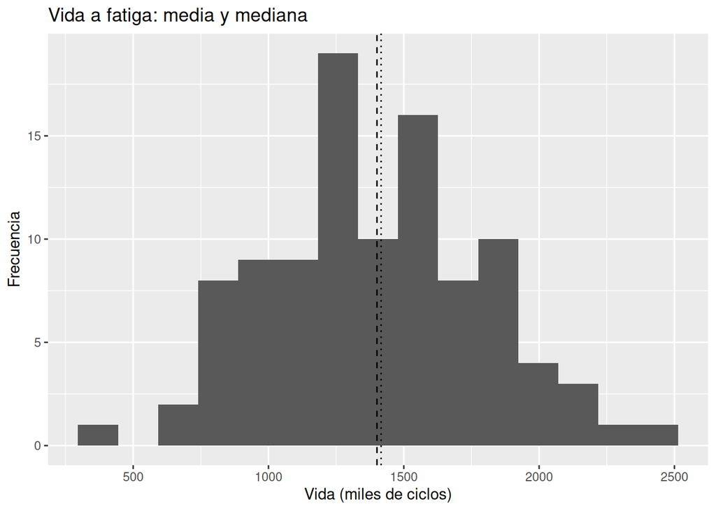

```r
ggplot(fatiga, aes(x = vida)) +
  geom_histogram(bins = 15) +
  geom_vline(
    xintercept = mean(fatiga$vida),
    linetype = 2
  ) +
  geom_vline(
    xintercept = median(fatiga$vida),
    linetype = 3
  ) +
  labs(
    title = "Vida a fatiga: media y mediana",
    x = "Vida (miles de ciclos)",
    y = "Frecuencia"
  )
```

## Actividad 1

Sin mirar todavía los números:

1. ¿Cuál esperas que sea mayor?
2. ¿Por qué?
3. ¿Qué característica de la distribución puede producir esa diferencia?

Después verifica:

```r
c(
  media = mean(fatiga$vida),
  mediana = median(fatiga$vida)
)
```

```
##    media  mediana
## 1400.911 1416.000
```

# 5. Sensibilidad de la media

Considera la muestra:

```r
x <- c(4, 5, 5, 6, 6, 7, 7, 8, 9)
mean(x)
```

```
## [1] 6.333333
```

```r
median(x)
```

```
## [1] 6
```

Agregamos una observación extrema:

```r
x_ext <- c(x, 100)

mean(x_ext)
```

```
## [1] 15.7
```

```r
median(x_ext)
```

```
## [1] 6.5
```

## Actividad 2

Explica algebraicamente por qué la media cambia más.

No basta decir “la media es sensible a valores extremos”.

Escribe qué ocurre con:

$$\bar x=\frac{1}{n}\sum x_i$$

cuando aparece una nueva observación $M$.

# 6. Cuantiles

```r
quantile(fatiga$vida)
```

```
##   0%  25%  50%  75% 100%
##  370 1115 1416 1642 2440
```

Podemos solicitar otros órdenes:

```r
quantile(
  fatiga$vida,
  probs = c(0.01, 0.10, 0.25, 0.50, 0.75, 0.90, 0.99)
)
```

```
##   1%  10%  25%  50%  75%  90%  99%
##  706  886 1115 1416 1642 1895 2268
```

Estos valores permiten localizar posiciones relativas.

# 7. Percentiles

El percentil $p$ es un cuantil asociado a una proporción acumulada.

Por ejemplo:

```r
quantile(fatiga$vida, 0.90)
```

```
##  90%
## 1895
```

Interpreta cuidadosamente:

> El percentil 90 **no** significa que una observación concreta “tenga 90%”.

Significa que aproximadamente 90% de las observaciones quedan por debajo del valor correspondiente, dependiendo del método de cálculo del cuantil.

# 8. Actividad 3 — Interpretación

Calcula:

```r
q <- quantile(fatiga$vida, c(.25, .5, .75))
q
```

```
##  25%  50%  75%
## 1115 1416 1642
```

Redacta:

- interpretación del primer cuartil;
- interpretación de la mediana;
- interpretación del tercer cuartil.

Después responde:

> ¿Qué porcentaje de las observaciones queda entre $Q_1$ y $Q_3$?

# 9. Moda

La moda no tiene por qué ser única.

En datos continuos, además, puede ser poco informativa si casi todos los valores son distintos.

Construye una función sencilla:

```r
moda <- function(x) {
  ux <- unique(x)
  ux[which.max(tabulate(match(x, ux)))]
}

moda(michelson$velocidad)
```

```
## [1] 299.88
```

## Actividad 4

¿Te parece una buena medida de centro para la velocidad de la luz?

Justifica tu respuesta estadísticamente.

# 10. Comparación de dos centros

```r
resumen <- data.frame(
  conjunto = c("Michelson", "Fatiga"),
  media = c(mean(michelson$velocidad), mean(fatiga$vida)),
  mediana = c(median(michelson$velocidad), median(fatiga$vida))
)

resumen
```

```
##    conjunto     media mediana
## 1 Michelson  299.8524  299.85
## 2    Fatiga 1400.9109 1416.00
```

No tiene sentido comparar directamente los valores numéricos de las dos variables porque están en escalas y unidades distintas.

## Idea clave

> Una estadística sólo puede interpretarse en el contexto de la variable y su unidad.

# Actividad integradora

Elige uno de los dos conjuntos y escribe un párrafo que incluya:

1. media;
2. mediana;
3. dos cuantiles;
4. interpretación;
5. comentario sobre posible asimetría.

# Autoevaluación

**Checklist**

Debes poder:

- calcular e interpretar media;
- calcular e interpretar mediana;
- explicar sensibilidad a valores extremos;
- definir cuantiles;
- interpretar percentiles;
- distinguir medida de centro de medida de posición;
- explicar por qué la unidad importa.

## Reto matemático

Demuestra que si se añade una observación $M$ a una muestra de tamaño $n$,

$$\bar x_{\text{nuevo}}
=
\frac{n\bar x+M}{n+1}.$$

¿Qué sucede con la media cuando $M\to\infty$?